# Final_Lab01_Introduction_to_Python_empty

## CS599 Biometrics

### Lab 01 on Python, NumPy and Pandas

#### 01/22/2026

Objective of this lab is to explore the NumPy and Matplotlib packages that provide capabilities for handling vectors, matrices, and Matlab-like plotting.

Based on Anaconda.com tutorials

## References

- [Python Tutorial](http://docs.python.org/2/tutorial/) - a good next step to learning Python (about a 2-3 hour commitment)
- [Python Reserved Words](http://docs.python.org/2/reference/lexical_analysis.html#keywords) - about 40 terms that form the base grammar of the language. NOTE: Thes are not functions.
- [Python builtin module](http://docs.python.org/2/library/functions.html#built-in-functions) functions (60) and classes (20)
- [Python Standard Library](http://docs.python.org/2/library/)
- [Python Package Index](https://pypi.python.org/pypi) community contributed Python packages
- [Idiomatic Python](http://python.net/~goodger/projects/pycon/2007/idiomatic/handout.html)

## Jupyter Hotkeys

There are many hotkeys to facilitate typing in Jupyter, here are a few of them:

| Jupyter Hotkey | Result |
| --- | --- |
| Enter | edit cell |
| Ctrl+Enter | run cell |
| Shift+Enter | run cell , go to next cell |
| a | add box above |
| b | add box below |
| y | to code |
| m | to markdown |
| r | to raw |
| c | copy cell |
| x | cut cell |
| d d | delete cell (click d twice) |
| v | paste cell below |
| Shift+v | paste cell above |
| o | toggle output |
| i i | interrupt kernel (click i twice) |

Note, a cell is selected with the leftbar is blue, and is being edited when it is green

Downloading and installing python, TensorFlow and Anaconda

https://www.python.org/

https://www.tensorflow.org/

https://www.anaconda.com/

# Numpy

NumPy is the fundamental package for scientific computing in Python. It is a Python library that provides a multidimensional array object, various derived objects (such as masked arrays and matrices), and an assortment of routines for fast operations on arrays, including mathematical, logical, shape manipulation, sorting, selecting, I/O, discrete Fourier transforms, basic linear algebra, basic statistical operations, random simulation and much more.

- a powerful N-dimensional array object that facilitate operations on large numbers of data.
- sophisticated (broadcasting) functions
- tools for integrating C/C++ and Fortran code
- useful linear algebra, Fourier transform, and random number capabilities
- Many Python-based scientific and mathematical packageds use NumPy array functionality

```python
a = 2
```

```python
!pip install numpy
```

```python
import numpy as np
# import numpy * -> imports all numpy function and can be called without prefix, i.e. array() = np.array()

s1 = np.array([1, 4, 9, 16, 25])  #create a row of five elements
```

```python
s2 = np.array([[1,2,3,4,5],
               [1,4,9,16,25],
               [1,8,27,64,125]])  # array of three rows and five columns
```

```python
s3 = np.array([2,5,10,17,26])
```

```python
s1
```

```
array([ 1,  4,  9, 16, 25])
```

```python
s2
```

```
array([[  1,   2,   3,   4,   5],
       [  1,   4,   9,  16,  25],
       [  1,   8,  27,  64, 125]])
```

Square brackets allow us to extract an element of the array at the given index. Note, the first element of the array is defined as 0, NOT 1

```python
s1[3]
```

```
np.int64(16)
```

You can extract multiple elements at once. Note, the final index is NOT included

```python
v1 = s1[1:4] # different from Python list slice which makes a copy.
# Numpy just copies references
# : means indexes from  1 to 4 but not including 4
```

```python
v1
```

```
array([ 4,  9, 16])
```

```python
s1[3] = 99 # you can assign values through slices
```

```python
s1
```

```
array([ 1,  4,  9, 99, 25])
```

Note that the above assignment will also change value in array `v1`. v1 and s1 point to the same array in memory

```python
v1
```

```
array([ 4,  9, 99])
```

```python
v1[0]  # first element of an array called by index 0, NOT 1
```

```
np.int64(4)
```

```python
v1[0] = 200
```

```python
v1
```

```
array([200,   9,  99])
```

```python
s1
```

```
array([  1, 200,   9,  99,  25])
```

```python
print(s1.dtype) # dtype method displays the element's class;
# s1 is a one-dimensional array
# type of elements is integer (int32)
print(s1.shape )
```

```
int64
(5,)
```

```python
type(s1) # function type displays the data structure or class: numeric array
```

```
numpy.ndarray
```

```python
s2  #to see the array you could also print s1
```

```
array([[  1,   2,   3,   4,   5],
       [  1,   4,   9,  16,  25],
       [  1,   8,  27,  64, 125]])
```

```python
print (s2)
```

```
[[  1   2   3   4   5]
 [  1   4   9  16  25]
 [  1   8  27  64 125]]
```

```python
s2[2]
# For a matrix, inputting a single index pulls out the corresponding row
# (here 2 means the 3rd row from the top)
```

```
array([  1,   8,  27,  64, 125])
```

```python
s2[:,2] #to extract a specific column
```

```
array([ 3,  9, 27])
```

If you want to select an entire row, # (number of row) followed by :. Note, if you have a matrix and want to be more precise (or to pick a column), write : in the non-prescribed row/column.

```python
s2[1:] # call all rows 1 and below
```

```
array([[  1,   4,   9,  16,  25],
       [  1,   8,  27,  64, 125]])
```

```python
s2[1:,:] # Here we explicitely indicate that we want all columns
```

```
array([[  1,   4,   9,  16,  25],
       [  1,   8,  27,  64, 125]])
```

```python
s2[:1] # slice array from the first row, index 0, to the row with index 1
# row with index 1 not included.
```

```
array([[1, 2, 3, 4, 5]])
```

```python
s2[:2] # slice array from the first row, index 0, to the row with index 2
# row with index 2 not included.
```

```
array([[ 1,  2,  3,  4,  5],
       [ 1,  4,  9, 16, 25]])
```

```python
s2[1,3] # call element in row with index 1, column with index 3
```

```
np.int64(16)
```

```python
s2   #let's print s2 again so that we can see it
```

```
array([[  1,   2,   3,   4,   5],
       [  1,   4,   9,  16,  25],
       [  1,   8,  27,  64, 125]])
```

```python
s2[:,::2] # all columns with even indices
```

```
array([[  1,   3,   5],
       [  1,   9,  25],
       [  1,  27, 125]])
```

```python
s2[:,::-1] # flips the order of the columns -- columns displayed backwards
```

```
array([[  5,   4,   3,   2,   1],
       [ 25,  16,   9,   4,   1],
       [125,  64,  27,   8,   1]])
```

```python
(s2[0])[::-1] # selects 0th row, flips the order of elements
```

```
array([5, 4, 3, 2, 1])
```

Addition and multiplication act element by element for arrays of equal dimensions

```python
s1
```

```
array([  1, 200,   9,  99,  25])
```

```python
s3
```

```
array([ 2,  5, 10, 17, 26])
```

```python
s1+s3
```

```
array([  3, 205,  19, 116,  51])
```

```python
s1*s3
```

```
array([   2, 1000,   90, 1683,  650])
```

# Broadcasting

Broadcasting allows us to add lower-dimensional arrays to higher-dimensional arrays

```python
s1
```

```
array([  1, 200,   9,  99,  25])
```

```python
s2
```

```
array([[  1,   2,   3,   4,   5],
       [  1,   4,   9,  16,  25],
       [  1,   8,  27,  64, 125]])
```

```python
s1 + s2 # s1 will be broadcast and added to each "row" in s2; s1 is 1x5 and s2 is 3x5
# we will often be adding a vector to each row or column in a matrix
```

```
array([[  2, 202,  12, 103,  30],
       [  2, 204,  18, 115,  50],
       [  2, 208,  36, 163, 150]])
```

```python
# a single column matrix with 3 rows
s3 = np.array([[1],[2],[0]])
s3
```

```
array([[1],
       [2],
       [0]])
```

```python
# added to 3x4 matrix
s2+s3
```

```
array([[  2,   3,   4,   5,   6],
       [  3,   6,  11,  18,  27],
       [  1,   8,  27,  64, 125]])
```

# Logical operations

```python
s2
```

```
array([[  1,   2,   3,   4,   5],
       [  1,   4,   9,  16,  25],
       [  1,   8,  27,  64, 125]])
```

```python
s2 > 10 # boolean selection array; turns numerical array into logical array
```

```
array([[False, False, False, False, False],
       [False, False, False,  True,  True],
       [False, False,  True,  True,  True]])
```

```python
s1
```

```
array([  1, 200,   9,  99,  25])
```

```python
s1 > 10 # creates an array of true/false indices
```

```
array([False,  True, False,  True,  True])
```

```python
s1[s1>10] # fancy indexing using boolean selection array:
# preserve elements of s1 that are greater than 10
# outputs numerical array (as opposed to above)
```

```
array([200,  99,  25])
```

```python
s2
```

```
array([[  1,   2,   3,   4,   5],
       [  1,   4,   9,  16,  25],
       [  1,   8,  27,  64, 125]])
```

```python
s2 >= s1 # logical broadcasting:
# takes s2 row by row and compares every row in s2 with s1
```

```
array([[ True, False, False, False, False],
       [ True, False,  True, False,  True],
       [ True, False,  True, False,  True]])
```

```python
s2[s2 >= s1]
#takes the matrix above and keeps numbers in position with True values
# note that it scans row by row and produces a row of values
```

```
array([  1,   1,   9,  25,   1,  27, 125])
```

```python
s1
```

```
array([  1, 200,   9,  99,  25])
```

```python
np.where(s1 > 10, 5, -2) # where function in Numpy select values as well.
# vectorized conditional: all values greater than 10, replace with 5,
# others, i.e., value less than 10, replace with -2
```

```
array([-2,  5, -2,  5,  5])
```

```python
np.where(s1 > 10, 'big', 'small')  # where clause.
# vectorized conditional: all values greater than 10, replace with 'big,'
# values less than 10, replace with 'small'.
# This turns numeric array into a string array.
```

```
array(['small', 'big', 'small', 'big', 'big'], dtype='<U5')
```

```python
np.where(s2 % 2 == 0, 'even', 'odd')# module division --modulus,
# if the remainder of dividing s2[] by 2 is 0, write even, if 1, write odd
```

```
array([['odd', 'even', 'odd', 'even', 'odd'],
       ['odd', 'even', 'odd', 'even', 'odd'],
       ['odd', 'even', 'odd', 'even', 'odd']], dtype='<U4')
```

```python
np.where(s2 > 10, 10, s2)
#if greater than 10 then print 10, if smaller than 10 then print value
```

```
array([[ 1,  2,  3,  4,  5],
       [ 1,  4,  9, 10, 10],
       [ 1,  8, 10, 10, 10]])
```

Numpy arrays are richer data structer than simple numerical matrices: can have logical arrays, string arrays, etc

# Basic Linear Algebra

## Important basic operations:

### Identity matrix

${\bf I} = \begin{bmatrix} 1&0&0\\0&1&0\\0&0&1\\ \end{bmatrix}$

```python
np.identity(3)
#identity function generates identity matrix of desired dimension
```

```
array([[1., 0., 0.],
       [0., 1., 0.],
       [0., 0., 1.]])
```

```python
np.identity(5)
```

```
array([[1., 0., 0., 0., 0.],
       [0., 1., 0., 0., 0.],
       [0., 0., 1., 0., 0.],
       [0., 0., 0., 1., 0.],
       [0., 0., 0., 0., 1.]])
```

## Vector addition:

${\bf s_1} = (a_1,b_1,c_1,d_1) = (1,200,9,99,25)$

${\bf s_3} = (a_3,b_3,c_3,d_3) = (2,5,10,17,26) $

${\bf s_1 + s_3} = (a_1,b_1,c_1,d_1) + (a_3,b_3,c_3,d_3) = (a_1+a_3, b_1+b_3, c_1+c_3, d_1+d_4) = (3,205,19,116,51)$

```python
s1 =np.array([1,200,9,99,25])
s2 =np.array([2,5,10,17,26])
```

```python
s1+s2  # adds arrays element by element
```

```
array([  3, 205,  19, 116,  51])
```

## Multiplication between a scalar and a vector:

$\beta {\bf A} = \beta(a_1,a_2,a_3) = (\beta a_1, \beta a_2, \beta a_3)$

$\beta = 2$

${\bf s_1} = (1,200,9,99,25)$

$\beta\ {\bf s_1} = (2,400,18,198,50)$

```python
s1
```

```
array([  1, 200,   9,  99,  25])
```

```python
a=2;
a*s1
```

```
array([  2, 400,  18, 198,  50])
```

## Element-wise multiplication:

```python
s1
```

```
array([  1, 200,   9,  99,  25])
```

```python
s3 = np.array([2,0.1,10,3,26])
```

```python
s1*s3 # multiplies elmenet by element
```

```
array([  2.,  20.,  90., 297., 650.])
```

```python
s2
```

```
array([ 2,  5, 10, 17, 26])
```

```python
s1*s2 #broadcasting multiplication: s1 multiplies every row in s2
```

```
array([   2, 1000,   90, 1683,  650])
```

## Determinant

The determinant is a useful quantity by which we can characterize square matrices

$ det\left|\begin{bmatrix} a&b\\ c&d\\ \end{bmatrix} \right| = ad - bc$

For a general $m\times m$ matrix one can use the Leibniz formula (see wiki or MathWorld)

```python
mm = np.random.randn(5,5)
mm
```

```
array([[ 0.30227016, -0.20483772,  0.30971865, -0.68965521,  0.22567806],
       [ 1.25766137, -1.55870632, -0.69657508, -1.85337473,  0.27672373],
       [-0.7991052 ,  1.21851364,  2.1231061 ,  0.50639747, -0.75630739],
       [-0.95055175,  0.75961924, -0.7633847 ,  0.17951362, -0.19752568],
       [ 1.99103237, -0.15529655, -0.62723104, -0.19182101,  0.5590344 ]])
```

```python
np.linalg.det(mm) #finds determinant; Numpy has linear algebra subpackage
```

```
np.float64(-2.459205929374109)
```

## Transpose:

$({\bf A}^T)_{i,j} = {\bf A}_{j,i}$

Element ij of a transpose matrix is element ji of the original matrix; note the flip in the indices

```python
s1
```

```
array([  1, 200,   9,  99,  25])
```

```python
np.transpose(s1) #recall from lecture that this transpose is a vertical vector
```

```
array([  1, 200,   9,  99,  25])
```

```python
# Numpy does not automatically display the transpose vector as vertical,
# You can do so by useing reshape.
s1vertical = s1.reshape(5,1)
```

```python
s1vertical
```

```
array([[  1],
       [200],
       [  9],
       [ 99],
       [ 25]])
```

```python
# Go back to the original vector
np.transpose (s1vertical)
```

```
array([[  1, 200,   9,  99,  25]])
```

```python
# With rectangular matricis the effects of transpose are easier to see
s2 = np.array([[1,2,3,4,5],
               [1,4,9,16,25],
               [1,8,27,64,125]])  # array of three rows and five columns
```

```python
np.transpose(s2) # with matrices you clearly see the transpose
```

```
array([[  1,   1,   1],
       [  2,   4,   8],
       [  3,   9,  27],
       [  4,  16,  64],
       [  5,  25, 125]])
```

## Inverse:

for a square matrix with non-zero determinant, we can take the inverse, which is defined for a 2x2 matrix as:

$\begin{bmatrix} a&b\\ c&d\\ \end{bmatrix} = \frac{1}{ad-bc} \begin{bmatrix}d&-b\\-c&a\end{bmatrix}$

a general $\bf m\times n$ matrix can be inverted by numeric methods such as Gauss-Jordan elimination, Gaussian elimination, or LU decomposition. Numpy does it automatically for us.

Note the determinant in the denominator

```python
s4 = np.array([[1,2],
               [1,4]])
```

```python
s4inv = np.linalg.inv(s4) # here's the linear algebra subpackage again;
# we want the inverse matrix
print(s4inv)
```

```
[[ 2.  -1. ]
 [-0.5  0.5]]
```

```python
# Element by element multiplication does not produce a unity matrix
s4*s4inv
```

```
array([[ 2. , -2. ],
       [-0.5,  2. ]])
```

```python
# np.matmul() function performs proper matrix multiplication
s44 = np.matmul(s4,s4inv)
```

```python
print(s44)
```

```
[[1. 0.]
 [0. 1.]]
```

```python
s5 = np.array([[1,2,3,4],
               [1,4,9,16],
               [1,8,27,64],
               [1,16,81,256]])
s6 = np.linalg.inv(s5)  #s6 is the inverse
s6
```

```
array([[ 4.        , -4.33333333,  1.5       , -0.16666667],
       [-3.        ,  4.75      , -2.        ,  0.25      ],
       [ 1.33333333, -2.33333333,  1.16666667, -0.16666667],
       [-0.25      ,  0.45833333, -0.25      ,  0.04166667]])
```

# Matrix multiplicaiton in Numpy

```python
s7 = np.matmul (s5,s6) #multiplying the two matrices
print (s7)
# note 1-s on the diagoal. All elements outside diagonal are very close to 0.
#This is just error of numeric calculation
```

```
[[ 1.00000000e+00 -2.22044605e-16 -4.44089210e-16 -5.55111512e-17]
 [ 1.33226763e-15  1.00000000e+00 -2.66453526e-15 -1.11022302e-16]
 [-3.55271368e-15  1.77635684e-14  1.00000000e+00  8.88178420e-16]
 [ 1.42108547e-14  1.42108547e-14  0.00000000e+00  1.00000000e+00]]
```

## The inner (dot) and outer products are defined by the dot and outer funtions

### Dot product:

In general

${\bf A\cdot B} = {\bf A^T B}= \begin{bmatrix}a_1&a_2&a_3\end{bmatrix} \begin{bmatrix} b_1\\ b_2\\ b_3\\ \end{bmatrix}=a_1 b_1 + a_2 b_2 + a_3 b_3$

Or for our vectors $\bf s_1$ and $\bf s_3$

The dot product gives you a scalar

```python
s1
```

```
array([  1, 200,   9,  99,  25])
```

```python
s3
```

```
array([ 2. ,  0.1, 10. ,  3. , 26. ])
```

```python
np.dot(s1,s3) # dot product -- dot product of two vectors is a scalar
```

```
np.float64(1059.0)
```

### Outer product

$ {\bf A\otimes B} = {\bf A B^T} = \begin{bmatrix} a_1\\ a_2\\ a_3\\ \end{bmatrix} \begin{bmatrix}b_1&b_2&b_3\end{bmatrix} = \begin{bmatrix} a_1b_1&a_1b_2&a_1b_3\\ a_2b_1&a_2b_2&a_2b_3\\ a_3b_1&a_3b_2&a_3b_3\\ \end{bmatrix} $

```python
np.outer(s1,s3)  # matrix multiplication or outer product (or cartesian product)
```

```
array([[2.000e+00, 1.000e-01, 1.000e+01, 3.000e+00, 2.600e+01],
       [4.000e+02, 2.000e+01, 2.000e+03, 6.000e+02, 5.200e+03],
       [1.800e+01, 9.000e-01, 9.000e+01, 2.700e+01, 2.340e+02],
       [1.980e+02, 9.900e+00, 9.900e+02, 2.970e+02, 2.574e+03],
       [5.000e+01, 2.500e+00, 2.500e+02, 7.500e+01, 6.500e+02]])
```

### Cross product

An additional product that is valid for vectors that are 3-elements in length is the cross product (a more generalized form is the outer product).

$ {\bf A\times B} = (a_1,a_2,a_3)\times(b_1,b_2,b3) = (a_2b_3-a_3b_2, a_3b_1-a_1b_3, a_1b_2-a_2b_2) $

Lenght/norm of the cross product is the area of the rhombus defined by vectors s1 and s3. The direction of that vector is orthogonal to the plane defined by vectors s1 and s3

```python
s6 = np.array([1,2,3])
s7 = np.array([4,5,6])

np.cross(s6,s7)
```

```
array([-3,  6, -3])
```

## Special kinds of matrices and vectors

The following assumes that you are working with square matrices, i.e. $m=n$

### Diagonal matrices

$ {\bf A} = \begin{bmatrix} a_1&0&0\\0&a_2&0\\0&0&a_3\\ \end{bmatrix} $

Where $A_{i,j} = 0$ if $i\neq j$

### Symmetric matrices

A matrix is symmetric if it is equal to its transpose, i.e.:

${\bf A = A^T} $

```python
s8 = np.array([[1,7,3],  # a symmetric matrix. The transpose will equal the original matrix
               [7,4,-5],
               [3,-5,6]])

np.transpose(s8)
```

```
array([[ 1,  7,  3],
       [ 7,  4, -5],
       [ 3, -5,  6]])
```

## Orthonormal vectors

A collection of real vectors $v_1, v_2, v_3, etc., $ is orthonormal if

- vectors have unit norm $||a_i|| = 1$
- they are mutuall orthogonal: $a_i^Ta_j=0 \text{ if } i\ne j$
- the square of the norm is equal to the dot product of the vector with itself

```python
e1 = np.array([0,0,-1]) # z-coordinate is -1
e2 = np.array([1/np.sqrt(2),1/np.sqrt(2),0])
#two orthonormal vectors; x and y-coordinates are 1/(square root of 2);norm
e3 = 1/np.sqrt(2)*np.array([1,-1,0])
#e2 and e3 are both in the xy plane; e3 is e2 rotated by 90 degrees
```

e1, e2 and e3 are three mutually orthonormal vectors because:

```python
np.dot(e1,e2)
```

```
np.float64(0.0)
```

```python
np.dot(e2,e3)
```

```
np.float64(0.0)
```

```python
np.dot(e3,e1)
```

```
np.float64(0.0)
```

We prove that the vectors are normal when their dot product is zero. You can think of these three vectors as the new basis vectors for the three dimensional space

### Orthogonal matrices

A matrix is orthogonal if it is a square matrix whose rows are mutually orthonormal and whose columns are mutually orthonormal:

${\bf A^T A = A A^T= I}$

This implies that ${\bf A^{-1} = A^T}$

```python
m1 = np.array([[0,1,0,0],
              [0,0,0,1],
              [1,0,0,0],
              [0,0,1,0]])

m2 = np.array([[0,0,1,0],
              [1,0,0,0],
              [0,0,0,1],
              [0,1,0,0]])

np.dot(m1,m2)
```

```
array([[1, 0, 0, 0],
       [0, 1, 0, 0],
       [0, 0, 1, 0],
       [0, 0, 0, 1]])
```

## Eigen-decomposition

Good discussion of this in ch2 of the Deep Learning book we provided. Often, we can better understand mathematical objects by breaking them into constitutient parts. An example of this is when you decompose a number into its prime factors, for example 12 = 2 x 2 x 3. In a similar way, decomposing a matrix into its eigenvalues and eigenverctors can give us information about a matrix that is not obvious from its representation as an array.

An eigenvector of a square matrix ${\bf A}$ is a non-zero vector $\bf v$ such that multiplication by $\bf A$ alters only the scale of $\bf v$:

${\bf A v} = \lambda {\bf v}$

The scalar $\lambda$ is known as the eigenvalue corresponding to the eigenvector

```python
A = np.array( [[4,0,1],
              [2,-2,3],
              [7,5,0]])

v = np.array([1,1,2])

np.dot(A,v)
```

```
array([ 6,  6, 12])
```

```python
6*v   # so we can see that the eigenvalue for v is 6;
```

```
array([ 6,  6, 12])
```

```python
dm = np.diag((1,2,3)) #create a diagonal matrix with 1,2,3 along the diagonal
```

```python
dm
```

```
array([[1, 0, 0],
       [0, 2, 0],
       [0, 0, 3]])
```

```python
np.linalg.eig(dm) # eig function calculates eigenvectors;
# creates an array with the eigenvalues in the first row
# [1., 2., 3.] are the eigenvalues.
# But it also gives you a matrix with the eigenvectors, in which the first row contains
# the eigenvalues and the second
# and remaining rows are the eigenvectors. In other words, this is an array with 2 parts,
# the first contains a vector of eigenvalues and the second contains the eigenvectors
```

```
EigResult(eigenvalues=array([1., 2., 3.]), eigenvectors=array([[1., 0., 0.],
       [0., 1., 0.],
       [0., 0., 1.]]))
```

```python
np.dot(dm,[1,0,0])
# dot products of the diagonal matrix and every eigenvector will give us the eigenvalues
```

```
array([1, 0, 0])
```

```python
np.dot(dm,[0,1,0])
```

```
array([0, 2, 0])
```

```python
np.dot(dm,[0,0,1])
```

```
array([0, 0, 3])
```

# Pandas

Pandas is a software library for Python for data manipulation and analysis with an emphasis on operations on numerical tables. Several attractive and popular features of pandas:

- Robust data input/output capabilities with integrated indexing
- Powerful API on top of NumPy `ndarray` data structure
- Analog to R DataFrame
- Versatile data visualization capabilities: matrix or database table.
- Specific charateristic:
  - Pandas are similar to R DataFrames and Excel file.
  - Data alignment and integrated handling of missing data.
  - Reshaping and pivoting of data sets.
  - Label-based slicing, fancy indexing,[3] and subsetting of large data sets.
  - Data structure column insertion and deletion.
  - Group by engine allowing split-apply-combine operations on data sets.
  - Data set merging and joining.
  - Hierarchical axis indexing to work with high-dimensional data in a lower-dimensional data structure.
  - Time series-functionality:
  - SQL like syntax for extraction of rows and columns

# Supported data formats:

- CSV
- Excel
- SQL
- JSON
- HDF5
- pickle
- msgpack
- Stata
- BigQuery

To show what Pandas can do we will look at data on Latin American politicans contained in a text file

```python
!pip install pandas
```

```python
import sys
import numpy as np
import pandas as pd

pd.options.display.max_rows = 20
pd.options.display.max_columns = 15
pd.__version__
```

```
'2.3.2'
```

```python
import sys  #system package that allows you to extract info about the computer itself.
# This module provides access to some variables used or maintained by the interpreter
# and to functions that interact strongly with the interpreter. It is always available
```

```python
sys.path
```

```
['c:\\Python313\\python313.zip',
 'c:\\Python313\\DLLs',
 'c:\\Python313\\Lib',
 'c:\\Python313',
 '',
 'C:\\Users\\mleen\\AppData\\Roaming\\Python\\Python313\\site-packages',
 'C:\\Users\\mleen\\AppData\\Roaming\\Python\\Python313\\site-packages\\win32',
 'C:\\Users\\mleen\\AppData\\Roaming\\Python\\Python313\\site-packages\\win32\\lib',
 'C:\\Users\\mleen\\AppData\\Roaming\\Python\\Python313\\site-packages\\Pythonwin',
 'c:\\Python313\\Lib\\site-packages']
```

```python
sitepkgs = r"C:\Users\mleen\michael_sandbox\metcs599\labs\lab1"
#file in my directory
testfile = "utf16_ex.txt" # file contains data on politicians from various countries
```

```python
import os

path = os.path.join(sitepkgs, testfile)
```

```python
data = pd.read_csv(path, sep="\t", encoding="utf-16", parse_dates=["Date"])
# reads the data (like an excel spread sheet -- first row has column names, Pandas adds row numbers)
# \t means it separates by tab: sep declares elements are separates;
# encoding declares what sort of unicode to use;
# and parse_dates deals with the dates (Pandas is pretty good at recognizing dates.)
```

```python
data  # native to pandas; prints the data
```

|  | Country | State/City | Title | Date | Catalogue | Wikipedia Election Page | Wikipedia Individual Page | Electoral Institution in Country | Twitter | CANDIDATE NAME 1 | CANDIDATE NAME 2 |
| --- | --- | --- | --- | --- | --- | --- | --- | --- | --- | --- | --- |
| 0 | Venezuela | NaN | President | 2012-10-07 | Hugo Rafael Chavez Frias | Hugo Chávez | Hugo Chávez | Hugo Chavez | Hugo Chávez Frías | Hugo Chavez | Hugo Chávez |
| 1 | Venezuela | NaN | President | 2012-10-07 | Henrique Capriles Radonski | Henrique Capriles Radonski | Henrique Capriles Radonski | Henrique Capriles Radonski | Henrique Capriles R. | Henrique Capriles | NaN |
| 2 | Venezuela | NaN | President | 2012-10-07 | Maria Josefina Bolivar | María Bolívar | María Bolívar | Maria Bolivar | Maria Bolivar | Maria Bolivar | María Bolívar |
| 3 | Venezuela | NaN | President | 2012-10-07 | Orlando Chirino | Orlando Chirinos | None. | Orlando Chirino | Orlando Chirino | Orlando Chirino | NaN |
| 4 | Venezuela | NaN | President | 2012-10-07 | Luis Reyes | Luis Reyes Castillo | None. | Luis Reyes | Luis Reyes | Luis Reyes | NaN |
| ... | ... | ... | ... | ... | ... | ... | ... | ... | ... | ... | ... |
| 45 | NaN | NaN | NaN | NaT | NaN | NaN | NaN | NaN | NaN | NaN | NaN |
| 46 | NaN | NaN | NaN | NaT | NaN | NaN | NaN | NaN | NaN | NaN | NaN |
| 47 | NaN | NaN | NaN | NaT | NaN | NaN | NaN | NaN | NaN | NaN | NaN |
| 48 | NaN | NaN | NaN | NaT | NaN | NaN | NaN | NaN | NaN | NaN | NaN |
| 49 | NaN | NaN | NaN | NaT | NaN | NaN | NaN | NaN | NaN | NaN | NaN |

50 rows × 11 columns

```python
data.dropna(subset=['Country', 'Date', 'Title'], inplace=True) # remove objects with empty sets correspond to the columns
# drops rows 43 and on. If anywhere there's an NaN in those columns, it will drop that row.
# Pandas can drop rows that have non-defined values, or you can replace those values with
# specified values
```

```python
data
```

|  | Country | State/City | Title | Date | Catalogue | Wikipedia Election Page | Wikipedia Individual Page | Electoral Institution in Country | Twitter | CANDIDATE NAME 1 | CANDIDATE NAME 2 |
| --- | --- | --- | --- | --- | --- | --- | --- | --- | --- | --- | --- |
| 0 | Venezuela | NaN | President | 2012-10-07 | Hugo Rafael Chavez Frias | Hugo Chávez | Hugo Chávez | Hugo Chavez | Hugo Chávez Frías | Hugo Chavez | Hugo Chávez |
| 1 | Venezuela | NaN | President | 2012-10-07 | Henrique Capriles Radonski | Henrique Capriles Radonski | Henrique Capriles Radonski | Henrique Capriles Radonski | Henrique Capriles R. | Henrique Capriles | NaN |
| 2 | Venezuela | NaN | President | 2012-10-07 | Maria Josefina Bolivar | María Bolívar | María Bolívar | Maria Bolivar | Maria Bolivar | Maria Bolivar | María Bolívar |
| 3 | Venezuela | NaN | President | 2012-10-07 | Orlando Chirino | Orlando Chirinos | None. | Orlando Chirino | Orlando Chirino | Orlando Chirino | NaN |
| 4 | Venezuela | NaN | President | 2012-10-07 | Luis Reyes | Luis Reyes Castillo | None. | Luis Reyes | Luis Reyes | Luis Reyes | NaN |
| ... | ... | ... | ... | ... | ... | ... | ... | ... | ... | ... | ... |
| 38 | Ecuador | NaN | President | 2013-02-07 | Lucio Edwin Gutiérrez Borbúa | Lucio Gutiérrez | Lucio Gutiérrez | Lucio Gutiérrez | Lucio Gutiérrez | Lucio Gutierrez | Lucio Gutiérrez |
| 39 | Ecuador | NaN | President | 2013-02-07 | Álvaro Fernando Noboa Pontón | Álvaro Noboa | Álvaro Noboa | Alvaro Noboa | Alvaro Noboa | Alvaro Noboa | Álvaro Noboa |
| 40 | Ecuador | NaN | President | 2013-02-07 | Alberto Acosta Espinosa | Alberto Acosta Espinosa | Alberto Acosta Espinosa | Alberto Acosta | Alberto Acosta | Alberto Acosta | NaN |
| 41 | Ecuador | NaN | President | 2013-02-07 | Mauricio Rodas Espinel | Mauricio Rodas | Mauricio Rodas | Mauricio Rodas | Mauricio Rodas | Mauricio Rodas | NaN |
| 42 | Ecuador | NaN | President | 2013-02-07 | Norman Wray | Norman Wray | None. | Norman Wray | Norman Wray | Norman Wray | NaN |

43 rows × 11 columns

```python
!pip install xlwt
# Library to write older version of Excel file
```

```python
!pip install openpyxl
```

```python
data.to_excel('people.xlsx')
# exporting function specific to pandas -- takes your data set and exports it into excel file
```

```python
data[data.Country == 'Chile'] #selecting data for Chile only
```

|  | Country | State/City | Title | Date | Catalogue | Wikipedia Election Page | Wikipedia Individual Page | Electoral Institution in Country | Twitter | CANDIDATE NAME 1 | CANDIDATE NAME 2 |
| --- | --- | --- | --- | --- | --- | --- | --- | --- | --- | --- | --- |
| 6 | Chile | Santiago | Mayor | 2012-10-28 | Carolina Montserrat Toha Morales | Carolina Tohá Morales | Carolina Tohá | Carolina Toha Morales | Carolina Tohá | Carolina Tohá | Carolina Toha |
| 7 | Chile | Santiago | Mayor | 2012-10-29 | Pablo Zalaquett Said | Pablo Zalaquett Said | Pablo Zalaquett | Pablo Zalaquett Said | Pablo Zalaquett Said | Pablo Zalaquett | NaN |
| 8 | Chile | Santiago | Mayor | 2012-10-30 | Waldo Mora Longa | Waldo Mora Longa | None. | Waldo Mora Longa | Waldo Mora L. | Waldo Mora | NaN |
| 9 | Chile | Santiago | Mayor | 2012-10-31 | Mario Aguilar | Mario Aguilar Arevalo | None. | Mario Aguilar Arevalo | Mario Aguilar | Mario Aguilar | NaN |
| 10 | Chile | Santiago | Mayor | 2012-11-01 | Ivan Carrasco | Iván Carrasco Mora | None. | Ivan Carrasco Mora | None. | Iván Carrasco Mora | Ivan Carrasco Mora |

```python
data[data.Date < '2012-11'] #selecting dates before November 2012
```

|  | Country | State/City | Title | Date | Catalogue | Wikipedia Election Page | Wikipedia Individual Page | Electoral Institution in Country | Twitter | CANDIDATE NAME 1 | CANDIDATE NAME 2 |
| --- | --- | --- | --- | --- | --- | --- | --- | --- | --- | --- | --- |
| 0 | Venezuela | NaN | President | 2012-10-07 | Hugo Rafael Chavez Frias | Hugo Chávez | Hugo Chávez | Hugo Chavez | Hugo Chávez Frías | Hugo Chavez | Hugo Chávez |
| 1 | Venezuela | NaN | President | 2012-10-07 | Henrique Capriles Radonski | Henrique Capriles Radonski | Henrique Capriles Radonski | Henrique Capriles Radonski | Henrique Capriles R. | Henrique Capriles | NaN |
| 2 | Venezuela | NaN | President | 2012-10-07 | Maria Josefina Bolivar | María Bolívar | María Bolívar | Maria Bolivar | Maria Bolivar | Maria Bolivar | María Bolívar |
| 3 | Venezuela | NaN | President | 2012-10-07 | Orlando Chirino | Orlando Chirinos | None. | Orlando Chirino | Orlando Chirino | Orlando Chirino | NaN |
| 4 | Venezuela | NaN | President | 2012-10-07 | Luis Reyes | Luis Reyes Castillo | None. | Luis Reyes | Luis Reyes | Luis Reyes | NaN |
| 5 | Venezuela | NaN | President | 2012-10-07 | Reina Sequera | Reina Sequera | Reina Sequera | Reina Sequera | Reina Sequera | Reina Sequera | NaN |
| 6 | Chile | Santiago | Mayor | 2012-10-28 | Carolina Montserrat Toha Morales | Carolina Tohá Morales | Carolina Tohá | Carolina Toha Morales | Carolina Tohá | Carolina Tohá | Carolina Toha |
| 7 | Chile | Santiago | Mayor | 2012-10-29 | Pablo Zalaquett Said | Pablo Zalaquett Said | Pablo Zalaquett | Pablo Zalaquett Said | Pablo Zalaquett Said | Pablo Zalaquett | NaN |
| 8 | Chile | Santiago | Mayor | 2012-10-30 | Waldo Mora Longa | Waldo Mora Longa | None. | Waldo Mora Longa | Waldo Mora L. | Waldo Mora | NaN |
| 9 | Chile | Santiago | Mayor | 2012-10-31 | Mario Aguilar | Mario Aguilar Arevalo | None. | Mario Aguilar Arevalo | Mario Aguilar | Mario Aguilar | NaN |

```python
data.Country.unique()  #select unique country names without repetition
```

```
array(['Venezuela', 'Chile', 'Nicaragua', 'Ecuador'], dtype=object)
```

```python
data.Country #this is the entire Country column, and you can see repetition
```

```
0     Venezuela
1     Venezuela
2     Venezuela
3     Venezuela
4     Venezuela
        ...
38      Ecuador
39      Ecuador
40      Ecuador
41      Ecuador
42      Ecuador
Name: Country, Length: 43, dtype: object
```

```python
data.Country.value_counts()
```

```
Country
Venezuela    25
Ecuador       7
Nicaragua     6
Chile         5
Name: count, dtype: int64
```

# Matplotlib

Matplotlib is a Python 2D plotting library that is both approachable but still very capable of generating sophisticated images.

- Images are MATLAB-like for simple plotting
  - MATLAB-like features make matplotlib images easily incorporated into industry standards
- Default plot styles allow for rapid visualization of data
- Deep integration with Python libraries
- Reliant on other Python libraries such as NumPy

We will look at how to display data and functions

```python
!pip install matplotlib
```

```python
%matplotlib inline
# magic function, says that matplotlib will be included in IPython and makes outputs appear
# and be stored in the notebook
# important because you want your graphics in the jupyter notebook
```

```python
import numpy as np
from   pylab import *

n     = 200      # number of elements in array
x     = np.linspace(0,10,n) # creates a liner array of 200 elements between 0 and 10
# (can add additional term to define step size)
data  = np.sin(x) #for every element, calculate the sin
# note that unlike in mathematics, sin function accepts vector as its argument,
# and calcualtes sin for every element of this vector.
# You can also do this with a for loop that passes each scalar element in the vector,
# however the for loop is much slower than passing a vector to the sin() function
noise = np.random.randn(n)
# random normal distribution (generates values that are normally distributed around 0
# so you get positive and negative values) ; adding noise to the sin function;
# noise is a separte array
noise2 = np.random.normal(0,.1,n)
# 0 is the mean or center of the distribution, .1 is the standard deviation
```

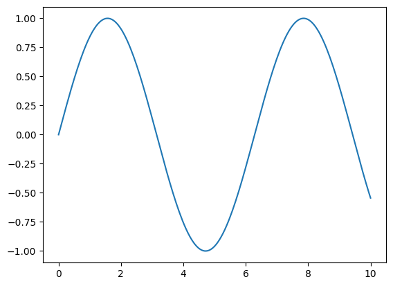

```python
plot(x,data) # here we plot the sin() function
```

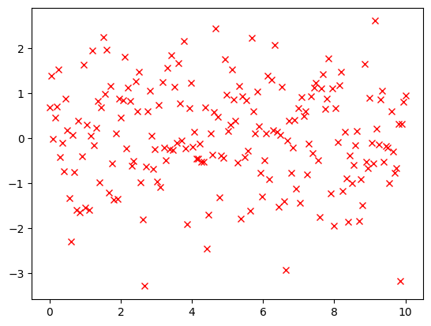

```python
plot(x,noise, 'rx') # here we plot the noise; note that the data points are dense around 0,
# which means the function does have a normal distribution
```

```python
np.max(noise) #maximum value produced by random functions
```

```
np.float64(2.6060952401529014)
```

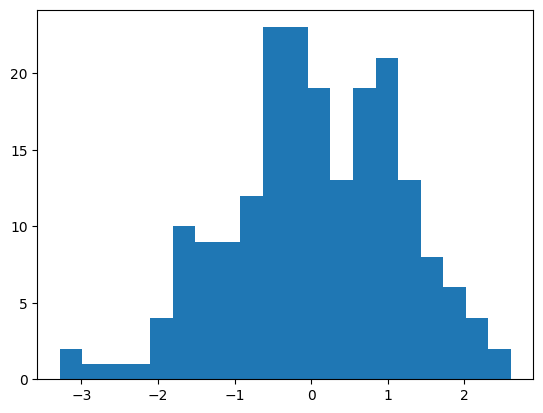

```python
hist(noise, 20)  # histogram is used to display radom distributions;
# We plot a histogram with 20 intervals that start at the negative max and go to the positive max
# the first array contains the values of the verticals in the histogram,
# and the second array are the coordinates of the intervals
```

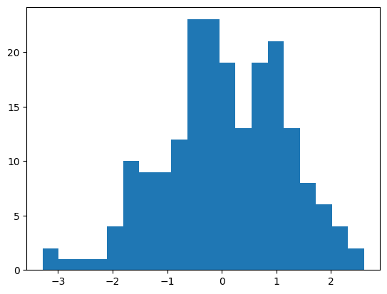

```python
_ = hist(noise, 20)
# if you don't want to print the values, use underscore;
# convention in Python is to use _ for throwaway variables
```

```python
print(_)
```

[output not shown]

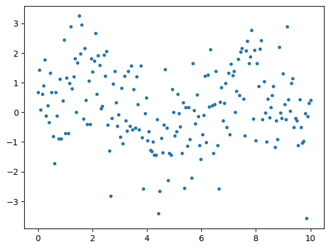

```python
obs = data + noise # a major component of our exprimental data is the sin() function,
# because our experiments are always stocahstic,
# we added noise; in other words, our observed values (obs) are sin() plus noise
# we add arrays element by element
plot(x, obs,'.')
# we get a plot that resembles a noisy sin() function
```

We can also show the sin() function superimposed with the noise

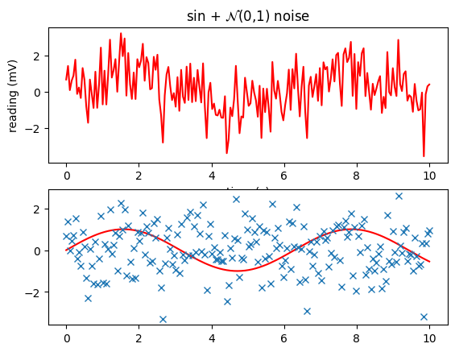

```python
obs = data + noise
figure()
subplot(211)  # declares a subplot of two rows and one column and selects the first,
#starting from top to bottom (left to right)
title('sin + $\mathcal{N}$(0,1) noise') #how you add titles to your displays
xlabel('time (s)') #how add labels to your graphs
ylabel('reading (mV)')
plot(x, obs, 'r')
subplot(212)
plot(x, data, 'r')
plot(x, noise, 'x')
show()
```

# Scipy

Python library used for scientific and technical computing. Contains modules for the following:

- Optimization & linear algebra
- Integration & interpolation
- Special functions (Bessel, ArcTan, Laguerre, etc...)
- Fast Fourier Transform (FFT)
- signal and image processing
- ODE solvers

Uses and expands on the capabilities of NumPy

The following example is a brief illustration of how convenient it is to use functions in Python and these packages, including Scipy.

```python
!pip install scipy
```

```python
import matplotlib.pyplot as plt
import numpy as np
import scipy as sp
import scipy.optimize
from numpy.random import rand
```

```python
'sp.optimize' in dir(sp)  #checks if sp package contains optimized subfunction
```

```
False
```

Again we want to show you how you can display various function. For example say we have a signal that can be described by the following function

$signal = A\times cos(2{\pi}x-1.32) + 0.22x$

```python
points = 200
x      = np.linspace(0, 10, points)  #defines points on the axis

# func-> A*cos(2pi*x-B)+x*C+noise
signal = 12.0 * np.cos(2*np.pi*x-1.32) + 0.22 * x
# we don't actually see the linear function .22x in our plot because it grows slowly
noise  = 4 * ((0.5-rand(points)) * np.exp(2*rand(points)**2)) #generating random noise again
combined = signal + noise
```

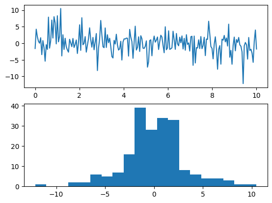

```python
figure()
subplot(211)
plot(x, noise)
subplot(212)
_ = hist(noise,20)
```

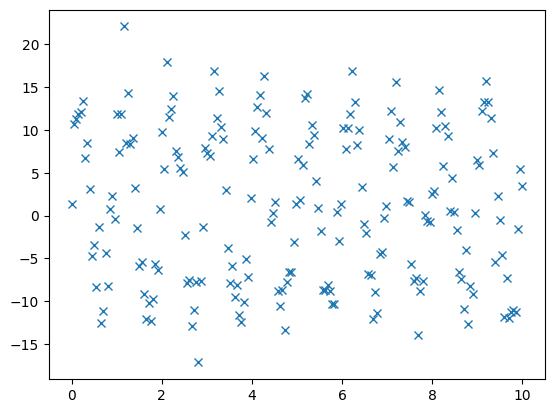

```python
plot(x, combined, 'x')
#plot(x, signal, 'o')
```

We generated a cos() function with noise. Now, we need to find a function that is a best fit. Inside the optimization subpackage we have the least square fit function that identifies the best fitting periodic function for experimental data:. We will call this function 'model' and it will have two variable: parameter 0 and parameter 1

$model = p_0 \times cos(2\pi x - p_1)$

```python
model = lambda p, x:    p[0] * np.cos(2*np.pi*x-p[1])
# the function we are trying to extract
# lambda operator, creates anonymous throwaway function of argument p,x, output p[0]...
# p is a vector of paramaters that we are looking for
err   = lambda p, x, y: model(p, x) - y
# also a lambda function that finds the error in the model compared to our
# experimental data; you subtract y values that were generated above by the original signal
# function
```

```python
guess = [1., 0.8]
fitted, success = sp.optimize.leastsq(err, guess, args=(x, combined))
# guess = starting values for the function;
# the function calculates errors for value iteratively, trying to minimize error
# it minimizes the sum of squares of a set of equations
```

```python
success
```

```
2
```

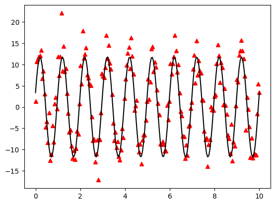

```python
plt.plot(x, combined,'r^')
plt.plot(x, model(fitted,x), 'k-')
# red is simulated experimental data;
#black lines is least square best fit (we used optimize function for that)
```

## Injest, analyze, and clean data with Pandas

## Example 1: Car catalog

```python
import pandas as pd

pd.set_option("display.max_rows",10)
```

```python
from  pandas.plotting import scatter_matrix
import matplotlib.pyplot as plt


# Load the datset of metrics for varios car models
file = r"C:\Users\mleen\michael_sandbox\metcs599\labs\lab1\Small_Car_Data.csv"
autompg = pd.read_csv(file)
no_rows = len(autompg.index)
no_columns = len(autompg.columns)
print("number of rows ",no_rows)
print("number of columns ", no_columns)

#attributes = ['Acceleration', 'Cylinders', 'Displacement', 'Horsepower','MPG']
#scatter_matrix(autompg[attributes], figsize=(12,8))

#plt.show();
```

```
number of rows  100
number of columns  11
```

```python
autompg  #prints the data
```

|  | Unnamed: 0 | Acceleration | Cylinders | Displacement | Horsepower | Manufacturer | Model | Model_Year | MPG | Origin | Weight |
| --- | --- | --- | --- | --- | --- | --- | --- | --- | --- | --- | --- |
| 0 | 1 | 12.0 | 8 | 307 | 130 | chevrolet | chevrolet chevelle malibu | 70 | 18.0 | USA | 3504 |
| 1 | 2 | 11.5 | 8 | 350 | 165 | buick | buick skylark 320 | 70 | 15.0 | USA | 3693 |
| 2 | 3 | 11.0 | 8 | 318 | 150 | plymouth | plymouth satellite | 70 | 18.0 | USA | 3436 |
| 3 | 4 | 12.0 | 8 | 304 | 150 | amc | amc rebel sst | 70 | 16.0 | USA | 3433 |
| 4 | 5 | 10.5 | 8 | 302 | 140 | ford | ford torino | 70 | 17.0 | USA | 3449 |
| ... | ... | ... | ... | ... | ... | ... | ... | ... | ... | ... | ... |
| 95 | 96 | 15.6 | 4 | 140 | 86 | ford | ford mustang gl | 82 | 27.0 | USA | 2790 |
| 96 | 97 | 24.6 | 4 | 97 | 52 | volkswagen | volkswagen pickup | 82 | 44.0 | Germany | 2130 |
| 97 | 98 | 11.6 | 4 | 135 | 84 | dodge | dodge rampage | 82 | 32.0 | USA | 2295 |
| 98 | 99 | 18.6 | 4 | 120 | 79 | ford | ford ranger | 82 | 28.0 | USA | 2625 |
| 99 | 100 | 19.4 | 4 | 119 | 82 | chevrolet | chevrolet s-10 | 82 | 31.0 | USA | 2720 |

100 rows × 11 columns

```python
type(autompg)
```

```
pandas.core.frame.DataFrame
```

```python
autompg.sort_values(by='MPG')
```

|  | Unnamed: 0 | Acceleration | Cylinders | Displacement | Horsepower | Manufacturer | Model | Model_Year | MPG | Origin | Weight |
| --- | --- | --- | --- | --- | --- | --- | --- | --- | --- | --- | --- |
| 34 | 35 | 18.5 | 8 | 304 | 193 | ih | ih 1200d | 70 | 9.0 | USA | 4732 |
| 31 | 32 | 14.0 | 8 | 360 | 215 | ford | ford f250 | 70 | 10.0 | USA | 4615 |
| 32 | 33 | 15.0 | 8 | 307 | 200 | chevrolet | chevrolet c20 | 70 | 10.0 | USA | 4376 |
| 33 | 34 | 13.5 | 8 | 318 | 210 | dodge | dodge d200 | 70 | 11.0 | USA | 4382 |
| 61 | 62 | 13.2 | 8 | 318 | 150 | plymouth | plymouth volare premier v8 | 76 | 13.0 | USA | 3940 |
| ... | ... | ... | ... | ... | ... | ... | ... | ... | ... | ... | ... |
| 87 | 88 | 16.2 | 4 | 91 | 67 | datsun | datsun 310 gx | 82 | 38.0 | Japan | 1995 |
| 89 | 90 | 17.0 | 6 | 262 | 85 | oldsmobile | oldsmobile cutlass ciera (diesel) | 82 | 38.0 | USA | 3015 |
| 80 | 81 | 14.7 | 4 | 105 | 63 | plymouth | plymouth horizon miser | 82 | 38.0 | USA | 2125 |
| 85 | 86 | 15.0 | 4 | 91 | 67 | honda | honda civic | 82 | 38.0 | Japan | 1965 |
| 96 | 97 | 24.6 | 4 | 97 | 52 | volkswagen | volkswagen pickup | 82 | 44.0 | Germany | 2130 |

100 rows × 11 columns

```python
autompg.sort_values(by='MPG',ascending=False) # ascending descending
```

|  | Unnamed: 0 | Acceleration | Cylinders | Displacement | Horsepower | Manufacturer | Model | Model_Year | MPG | Origin | Weight |
| --- | --- | --- | --- | --- | --- | --- | --- | --- | --- | --- | --- |
| 96 | 97 | 24.6 | 4 | 97 | 52 | volkswagen | volkswagen pickup | 82 | 44.0 | Germany | 2130 |
| 85 | 86 | 15.0 | 4 | 91 | 67 | honda | honda civic | 82 | 38.0 | Japan | 1965 |
| 89 | 90 | 17.0 | 6 | 262 | 85 | oldsmobile | oldsmobile cutlass ciera (diesel) | 82 | 38.0 | USA | 3015 |
| 80 | 81 | 14.7 | 4 | 105 | 63 | plymouth | plymouth horizon miser | 82 | 38.0 | USA | 2125 |
| 87 | 88 | 16.2 | 4 | 91 | 67 | datsun | datsun 310 gx | 82 | 38.0 | Japan | 1995 |
| ... | ... | ... | ... | ... | ... | ... | ... | ... | ... | ... | ... |
| 68 | 69 | 14.0 | 8 | 318 | 150 | dodge | dodge d100 | 76 | 13.0 | USA | 3755 |
| 33 | 34 | 13.5 | 8 | 318 | 210 | dodge | dodge d200 | 70 | 11.0 | USA | 4382 |
| 31 | 32 | 14.0 | 8 | 360 | 215 | ford | ford f250 | 70 | 10.0 | USA | 4615 |
| 32 | 33 | 15.0 | 8 | 307 | 200 | chevrolet | chevrolet c20 | 70 | 10.0 | USA | 4376 |
| 34 | 35 | 18.5 | 8 | 304 | 193 | ih | ih 1200d | 70 | 9.0 | USA | 4732 |

100 rows × 11 columns

```python
attributes = ['Acceleration', 'Cylinders', 'Displacement', 'Horsepower','MPG']
# panda allows us to pick a few columns, not the whole set
autompg[attributes]
```

|  | Acceleration | Cylinders | Displacement | Horsepower | MPG |
| --- | --- | --- | --- | --- | --- |
| 0 | 12.0 | 8 | 307 | 130 | 18.0 |
| 1 | 11.5 | 8 | 350 | 165 | 15.0 |
| 2 | 11.0 | 8 | 318 | 150 | 18.0 |
| 3 | 12.0 | 8 | 304 | 150 | 16.0 |
| 4 | 10.5 | 8 | 302 | 140 | 17.0 |
| ... | ... | ... | ... | ... | ... |
| 95 | 15.6 | 4 | 140 | 86 | 27.0 |
| 96 | 24.6 | 4 | 97 | 52 | 44.0 |
| 97 | 11.6 | 4 | 135 | 84 | 32.0 |
| 98 | 18.6 | 4 | 120 | 79 | 28.0 |
| 99 | 19.4 | 4 | 119 | 82 | 31.0 |

100 rows × 5 columns

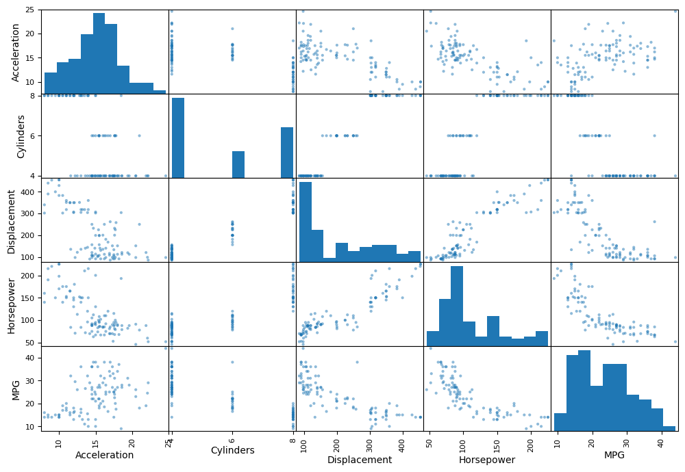

```python
attributes =['Acceleration', 'Cylinders', 'Displacement', 'Horsepower','MPG']
scatter_matrix(autompg[attributes], figsize=(12,8))
plt.show()
```

On the diagonal of the scatter matrix we see (statistical) distributions of values in respective column. The off diagonal plots present values in the row atribute as a function of values in the column attribute. Those off diagonal plots coupled with covariance matrices for each par of variables (attributes) tell us about mutual correlation between two variable (attributes). For example, Displacement and Horsepower are positively correlated. Displacement and MPG are negatively correlated. A broad cloud means little correlation beween two variables.

```python
autompg
```

|  | Unnamed: 0 | Acceleration | Cylinders | Displacement | Horsepower | Manufacturer | Model | Model_Year | MPG | Origin | Weight |
| --- | --- | --- | --- | --- | --- | --- | --- | --- | --- | --- | --- |
| 0 | 1 | 12.0 | 8 | 307 | 130 | chevrolet | chevrolet chevelle malibu | 70 | 18.0 | USA | 3504 |
| 1 | 2 | 11.5 | 8 | 350 | 165 | buick | buick skylark 320 | 70 | 15.0 | USA | 3693 |
| 2 | 3 | 11.0 | 8 | 318 | 150 | plymouth | plymouth satellite | 70 | 18.0 | USA | 3436 |
| 3 | 4 | 12.0 | 8 | 304 | 150 | amc | amc rebel sst | 70 | 16.0 | USA | 3433 |
| 4 | 5 | 10.5 | 8 | 302 | 140 | ford | ford torino | 70 | 17.0 | USA | 3449 |
| ... | ... | ... | ... | ... | ... | ... | ... | ... | ... | ... | ... |
| 95 | 96 | 15.6 | 4 | 140 | 86 | ford | ford mustang gl | 82 | 27.0 | USA | 2790 |
| 96 | 97 | 24.6 | 4 | 97 | 52 | volkswagen | volkswagen pickup | 82 | 44.0 | Germany | 2130 |
| 97 | 98 | 11.6 | 4 | 135 | 84 | dodge | dodge rampage | 82 | 32.0 | USA | 2295 |
| 98 | 99 | 18.6 | 4 | 120 | 79 | ford | ford ranger | 82 | 28.0 | USA | 2625 |
| 99 | 100 | 19.4 | 4 | 119 | 82 | chevrolet | chevrolet s-10 | 82 | 31.0 | USA | 2720 |

100 rows × 11 columns

```python
sorted(autompg.Manufacturer.unique())
```

```
['amc          ',
 'audi         ',
 'bmw          ',
 'buick        ',
 'cadillac     ',
 'chevrolet    ',
 'chrysler     ',
 'citroen      ',
 'datsun       ',
 'dodge        ',
 'fiat         ',
 'ford         ',
 'honda        ',
 'ih           ',
 'mazda        ',
 'mercedes-benz',
 'mercury      ',
 'nissan       ',
 'oldsmobile   ',
 'opel         ',
 'peugeot      ',
 'plymouth     ',
 'pontiac      ',
 'renault      ',
 'saab         ',
 'toyota       ',
 'volkswagen   ',
 'volvo        ']
```

```python
sorted(autompg.Manufacturer.value_counts())
```

```
[1,
 1,
 1,
 1,
 1,
 1,
 1,
 1,
 1,
 1,
 1,
 1,
 1,
 1,
 1,
 2,
 2,
 3,
 3,
 4,
 4,
 5,
 5,
 8,
 9,
 9,
 15,
 16]
```

```python
autompg.loc[autompg.Manufacturer == 'chevroelt', 'Manufacturer'] = 'chevrolet'
autompg.loc[autompg.Manufacturer == 'chevy',     'Manufacturer'] = 'chevrolet'
autompg.loc[autompg.Manufacturer == 'maxda',     'Manufacturer'] = 'mazda'
autompg.loc[autompg.Manufacturer == 'mercedes',  'Manufacturer'] = 'mercedes-benz'
autompg.loc[autompg.Manufacturer == 'toyouta',   'Manufacturer'] = 'toyota'
autompg.loc[autompg.Manufacturer == 'vokswagen', 'Manufacturer'] = 'volkswagen'
autompg.loc[autompg.Manufacturer == 'vw',        'Manufacturer'] = 'volkswagen'
```

```python
sorted(autompg.Manufacturer.unique())
```

```
['amc          ',
 'audi         ',
 'bmw          ',
 'buick        ',
 'cadillac     ',
 'chevrolet    ',
 'chrysler     ',
 'citroen      ',
 'datsun       ',
 'dodge        ',
 'fiat         ',
 'ford         ',
 'honda        ',
 'ih           ',
 'mazda        ',
 'mercedes-benz',
 'mercury      ',
 'nissan       ',
 'oldsmobile   ',
 'opel         ',
 'peugeot      ',
 'plymouth     ',
 'pontiac      ',
 'renault      ',
 'saab         ',
 'toyota       ',
 'volkswagen   ',
 'volvo        ']
```

```python
with pd.option_context('display.max_rows', 999):
    print(autompg.groupby('Manufacturer').size())
```

```
Manufacturer
amc               9
audi              1
bmw               1
buick             3
cadillac          1
chevrolet        15
chrysler          1
citroen           1
datsun            3
dodge             9
fiat              1
ford             16
honda             4
ih                1
mazda             2
mercedes-benz     1
mercury           1
nissan            1
oldsmobile        1
opel              1
peugeot           2
plymouth          8
pontiac           4
renault           1
saab              1
toyota            5
volkswagen        5
volvo             1
dtype: int64
```

## Example 2: Heat Map Representation of Correlations Between Variables

### Pearson Correlations

Seaborn is another popular Graphics Library like Matplotlib. We will demonstrate its heat-map functions

```python
!pip install seaborn
```

```
['Acceleration' 'Cylinders' 'Displacement' 'Horsepower' 'MPG']
```

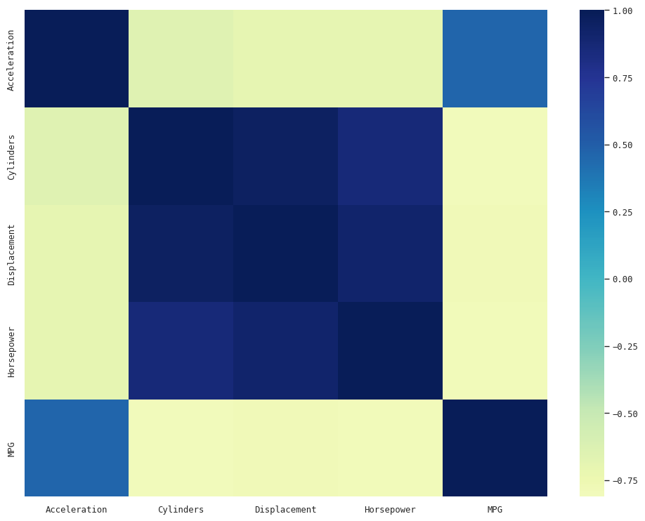

```python
import seaborn as sns
import matplotlib.pyplot as plt
import pandas as pd
sns.set(context="paper", font="monospace")
#sns.palplot(sns.color_palette("hls",4))

small_auto = autompg[attributes]
#no_rows = len(small_auto.index)
#no_columns = len(small_auto.columns)
#print("number of rows ",no_rows)
#print("number of columns ", no_columns)
print( small_auto.columns.values)

corrmat = small_auto.corr(method='pearson')

# Set up the matplotlib figure
f, ax = plt.subplots(figsize=(12, 9))

# Draw the heatmap using seaborn
sns.heatmap(corrmat,center=0, cmap="YlGnBu")
plt.show()
```

Positively correlated attributes intersect at dark blue squares. Negatively correlated attributes intersect and off-white squares.